# Selected Sections from Chapter 6: 6.5

[figure not shown]

© Scott Robison 2021 all rights reserved.

## 6.5 The Method of Moment-Generating Fuctions

> Refresh your memory of the [distributions](https://people.ucalgary.ca/~sarobiso/323/Distrbutions%20Summary.pdf) and their moment-generating functions (MGFs). It will be very important to be able to recognize MGFs easily.

> Please continue [reading](https://github.com/chqngh-berkeley/personal/blob/master/Mathematical%20Statistics%20-%207th%20Edition%20-%20Wackerly.pdf) pages 318-322 from the text.

Notable sections:

> THEOREM 6.1

> Let $M_X(t )$ and $M_Y(t )$ denote the moment-generating functions of random variables $X$ and $Y$, respectively. If both moment-generating functions exist and $M_X(t) = M_Y (t)$ for all values of $t$, then $X$ and $Y$ have the same probability distribution.

Recall:
$$M_X(t)=E[e^{Xt}]$$

$$\begin{aligned}
E[e^{xt}] & = \int_{\text{all }x}e^{xt}f_X(x)dx\text{ for continuous RV}\\
& =\sum_{\text{all }x}e^{xt}P_X(X=x)\text{ for discrete RV}\\
\end{aligned}$$

> THEOREM 6.2

> Let $X_1, X_2, . . . , X_n$ be independent random variables with moment- generating functions $M_{X_1} (t), M_{X_2} (t), . . . , M_{X_n} (t)$, respectively. If $U = X_1 + X_2 +···+X_n$,then:
> $$M_U (t) = M_{X_1} (t) × M_{X_2} (t) × · · · × M_{X_n} (t)$$

> THEOREM 6.3

> Let$X_1,X_2,...,X_n$ be independent normally distributed randomvariables with $E(X_i) = \mu_i$ and $V(X_i) =\sigma_i^2$, for $i = 1,2,...,n$, and let $a_1,a_2,...,a_n$ be constants. If
> $$U=\sum_{i=1}^{n}a_iX_i=a_1X_1+a_2X_2+...+a_nX_n$$
> Then $U$ is a normally distributed random variable, $U \sim Norm(\mu_U=E[U], \sigma^2_U=V[U])$, with
> $$E[U]=\sum_{i=1}^{n}a_i\mu_i=a_1\mu_1+a_2\mu_2+...+a_n\mu_n$$
> and
> $$V[U]=\sum_{i=1}^{n}a^2_i\sigma^2_i=a^2_1\sigma^2_1+a^2_2\sigma^2_2+...+a^2_n\sigma^2_n$$

> THEOREM 6.4

> Let $X_1,X_2,...,X_n$ be defined as in Theorem 6.3 and define $Z_i$ by
> $$Z_i=\frac{X_i-\mu_i}{\sigma_i}, i=1,2,...,n$$
> Then
> $$\sum_{i=1}^n Z_i^2 \text{ has a }\chi^2 \text{ distribution with } n \text{ degrees of freedom.}$$

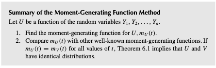

### Example 6.10

Suppose that $x$ is a normally distributed random variable with mean $\mu$ and variance $\sigma^2$. Show that
$$Z=\frac{X-\mu}{\sigma}$$
has a *standard normal distribution*, a normal distribution with mean 0 and variance 1.

### Solution

[video not shown]

[Example 6.10 hard copy solution](https://people.ucalgary.ca/~sarobiso/323/text%20soltutions/323%206_10.pdf)

### Example 6.11

Let $Z$ be a normally distributed random variable with mean 0 and variance 1. Use the method of moment-generating functions to find the probability distribution of $Z^2$.

### Solution

[video not shown]

[Example 6.11 hard copy solution](https://people.ucalgary.ca/~sarobiso/323/text%20soltutions/323%206_11.pdf)

### Example 6.12

The number of customer arrivals at a checkout counter in a given interval of time possesses approximately a Poisson probability distribution (see Section 3.8). If $X_1$ denotes the time until the first arrival, $X_2$ denotes the time between the first and second arrival, . . . , and X_n denotes the time between the $(n − 1)^\text{st}$ and $n^\text{th}$ arrival, then it can be shown that $X_1,X_2,...,X_n$ are independent random variables, with the density function for $X_i$ given by

$$\begin{align}f_{X_i}(x)=\begin{cases}
\frac{e^{-\frac{x}{\theta}}}{\theta},& x\ge 0,& \theta\ge 0 \\
0,& \text{otherwise }\\
\end{cases}
\end{align}$$

[Because the $X_i$ , for $i = 1, 2, . . . , n$, are exponentially distributed, it follows that $E(X_i) = \theta$; that is, $\theta$ is the average time between arrivals.] Find the probability density function for the waiting time from the opening of the counter until the nth customer arrives. (If $X_1, X_2, . . .$ denote successive interarrival times, we want the density function of $Y =X_1 +X_2 +···+X_n$.)

### Solution

[video not shown]

[Example 6.12 hard copy solution](https://people.ucalgary.ca/~sarobiso/323/text%20soltutions/323%206_12.pdf)

### Additional Examples

If $X\sim Normal(\mu,\sigma^2)$, What is the probability density function of $Z=\frac{X-\mu}{\sigma}$ ,$f_Z(z)$?

[video not shown]

[video not shown]

Let $X_1, X_2,$ and $X_3$ denote a random sample of size 3 from a gamma distribution with $\alpha = 7$ and $\beta = 5$. Let $Y$ be the sum of the three random variables: $Y=X_1+X_2+X_3$

1. What is the distribution of $Y$? Recall: $M_Y (t)=\prod_{i=1}^nM_X (t)=[M_X (t)]^n$
2. What is the distribution of $\overline{X}=\frac{Y}{3}$? Recall: $M_Y (t)=\prod_{i=1}^nM_X (t)=[M_X (t)]^n$

[video not shown]

> Please [**Practice**](https://github.com/chqngh-berkeley/personal/blob/master/Mathematical%20Statistics%20-%207th%20Edition%20-%20Wackerly.pdf) as many exercises from pages 322-325 as possible the odd questions have answers in the back of the text.

> This is where the real learning happens.